# Multi-Subject Validation of Physiological Responses

Jenna Lu

2026-07-27

# Overview

Physiological responses vary substantially between individuals.

This notebook extends the previous analyses from a single participant to multiple participants in the WESAD dataset.

The goals are:

1. Process heart rate features across multiple subjects
2. Evaluate subject-level variability
3. Compare physiological responses across conditions
4. Fit hierarchical statistical models accounting for repeated measurements

# Libraries

```r
library(tidyverse)
library(here)
library(lme4)
library(broom.mixed)
```

# Load Subject-Level ECG Data

The converted WESAD files contain ECG recordings for each participant.

We use the processed ECG files generated during preprocessing.

```r
files <- list.files(
  here("data", "processed"),
  pattern = "_ecg.csv$",
  full.names = TRUE
)


files
```

```
##  [1] "C:/Users/jenna/OneDrive/Documents/functional-physiology-analysis/data/processed/S10_ecg.csv"
##  [2] "C:/Users/jenna/OneDrive/Documents/functional-physiology-analysis/data/processed/S11_ecg.csv"
##  [3] "C:/Users/jenna/OneDrive/Documents/functional-physiology-analysis/data/processed/S13_ecg.csv"
##  [4] "C:/Users/jenna/OneDrive/Documents/functional-physiology-analysis/data/processed/S14_ecg.csv"
##  [5] "C:/Users/jenna/OneDrive/Documents/functional-physiology-analysis/data/processed/S15_ecg.csv"
##  [6] "C:/Users/jenna/OneDrive/Documents/functional-physiology-analysis/data/processed/S16_ecg.csv"
##  [7] "C:/Users/jenna/OneDrive/Documents/functional-physiology-analysis/data/processed/S17_ecg.csv"
##  [8] "C:/Users/jenna/OneDrive/Documents/functional-physiology-analysis/data/processed/S2_ecg.csv"
##  [9] "C:/Users/jenna/OneDrive/Documents/functional-physiology-analysis/data/processed/S3_ecg.csv"
## [10] "C:/Users/jenna/OneDrive/Documents/functional-physiology-analysis/data/processed/S4_ecg.csv"
## [11] "C:/Users/jenna/OneDrive/Documents/functional-physiology-analysis/data/processed/S5_ecg.csv"
## [12] "C:/Users/jenna/OneDrive/Documents/functional-physiology-analysis/data/processed/S6_ecg.csv"
## [13] "C:/Users/jenna/OneDrive/Documents/functional-physiology-analysis/data/processed/S7_ecg.csv"
## [14] "C:/Users/jenna/OneDrive/Documents/functional-physiology-analysis/data/processed/S8_ecg.csv"
## [15] "C:/Users/jenna/OneDrive/Documents/functional-physiology-analysis/data/processed/S9_ecg.csv"
```

# Extract Subject Information

```r
subject_data <- tibble(
  file = files
) %>%
  mutate(
    subject = str_extract(
      basename(file),
      "S[0-9]+"
    )
  )


subject_data
```

```
## # A tibble: 15 × 2
##    file                                                                  subject
##    <chr>                                                                 <chr>
##  1 C:/Users/jenna/OneDrive/Documents/functional-physiology-analysis/dat… S10
##  2 C:/Users/jenna/OneDrive/Documents/functional-physiology-analysis/dat… S11
##  3 C:/Users/jenna/OneDrive/Documents/functional-physiology-analysis/dat… S13
##  4 C:/Users/jenna/OneDrive/Documents/functional-physiology-analysis/dat… S14
##  5 C:/Users/jenna/OneDrive/Documents/functional-physiology-analysis/dat… S15
##  6 C:/Users/jenna/OneDrive/Documents/functional-physiology-analysis/dat… S16
##  7 C:/Users/jenna/OneDrive/Documents/functional-physiology-analysis/dat… S17
##  8 C:/Users/jenna/OneDrive/Documents/functional-physiology-analysis/dat… S2
##  9 C:/Users/jenna/OneDrive/Documents/functional-physiology-analysis/dat… S3
## 10 C:/Users/jenna/OneDrive/Documents/functional-physiology-analysis/dat… S4
## 11 C:/Users/jenna/OneDrive/Documents/functional-physiology-analysis/dat… S5
## 12 C:/Users/jenna/OneDrive/Documents/functional-physiology-analysis/dat… S6
## 13 C:/Users/jenna/OneDrive/Documents/functional-physiology-analysis/dat… S7
## 14 C:/Users/jenna/OneDrive/Documents/functional-physiology-analysis/dat… S8
## 15 C:/Users/jenna/OneDrive/Documents/functional-physiology-analysis/dat… S9
```

# Load Heart Rate Data

The heart rate files generated previously are combined across participants.

```r
hr_files <- list.files(
  here("data", "processed"),
  pattern = "_heart_rate.csv$",
  full.names = TRUE
)


hr_all <- map_dfr(
  hr_files,
  function(file){

    subject <- str_extract(
      basename(file),
      "S[0-9]+"
    )

    read_csv(file) %>%
      mutate(
        subject = subject
      )

  }
)
glimpse(hr_all)
```

```
## Rows: 104,632
## Columns: 3
## $ time       <dbl> 1.562857, 2.195714, 2.821429, 3.445714, 4.072857, 4.697143,…
## $ heart_rate <dbl> 94.59459, 94.80813, 95.89041, 96.10984, 95.67198, 96.10984,…
## $ subject    <chr> "S10", "S10", "S10", "S10", "S10", "S10", "S10", "S10", "S1…
```

# Summary of Participants

```r
hr_all %>%
  count(subject)
```

```
## # A tibble: 15 × 2
##    subject     n
##    <chr>   <int>
##  1 S10      6465
##  2 S11      7160
##  3 S13      7862
##  4 S14      7392
##  5 S15      6945
##  6 S16      7243
##  7 S17      7140
##  8 S2       5433
##  9 S3       6501
## 10 S4       6952
## 11 S5       7287
## 12 S6       8365
## 13 S7       6157
## 14 S8       6884
## 15 S9       6846
```

# Load Condition Labels

Because heart rate occurs at detected beat locations, conditions are matched using the original ECG timestamps.

```r
ecg_files <- list.files(
  here("data", "processed"),
  pattern="_ecg_filtered.csv$",
  full.names=TRUE
)
```

# Create Subject-Level Condition Data

```r
condition_all <- map_dfr(
  ecg_files,
  function(file){

    subject <- str_extract(
      basename(file),
      "S[0-9]+"
    )

    read_csv(file) %>%
      select(time, label) %>%
      mutate(
        subject = subject
      )

  }
)
head(condition_all)
```

```
## # A tibble: 6 × 3
##      time label subject
##     <dbl> <dbl> <chr>
## 1 0           0 S10
## 2 0.00143     0 S10
## 3 0.00286     0 S10
## 4 0.00429     0 S10
## 5 0.00571     0 S10
## 6 0.00714     0 S10
```

# Align Heart Rate With Conditions

```r
hr_condition_all <- hr_all %>%
  group_by(subject) %>%
  group_modify(
    ~{

      subject_id <- .y$subject

      labels <- condition_all %>%
        filter(subject == subject_id) %>%
        arrange(time)

      .x %>%
        mutate(
          label = labels$label[
            findInterval(
              time,
              labels$time
            )
          ]
        )

    }
  ) %>%
  ungroup()
```

# Condition Summary Across Subjects

```r
hr_condition_all %>%
  group_by(label) %>%
  summarise(
    mean_hr = mean(heart_rate),
    sd_hr = sd(heart_rate),
    n = n()
  )
```

```
## # A tibble: 8 × 4
##   label mean_hr sd_hr     n
##   <dbl>   <dbl> <dbl> <int>
## 1     0    77.6  15.7 47828
## 2     1    73.4  13.2 20678
## 3     2    86.2  18.5 13460
## 4     3    74.0  13.1  6540
## 5     4    70.9  12.6 13083
## 6     5    79.0  14.0  1007
## 7     6    82.5  16.0  1035
## 8     7    76.3  12.0  1001
```

# Subject Variability

Individuals may have different baseline heart rates.

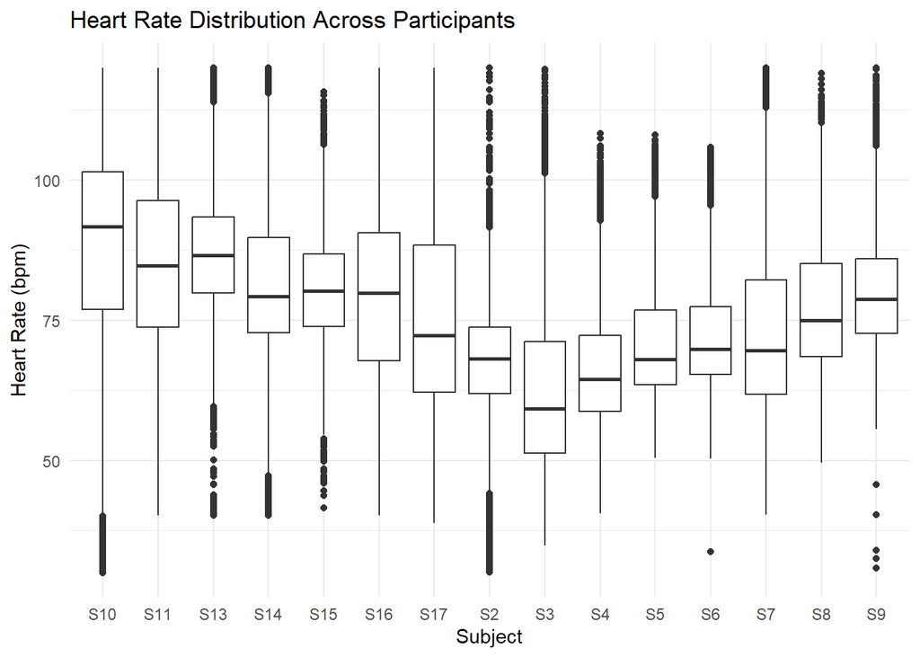

```r
hr_condition_all %>%
  ggplot(
    aes(
      x=subject,
      y=heart_rate
    )
  ) +
  geom_boxplot() +
  labs(
    title="Heart Rate Distribution Across Participants",
    x="Subject",
    y="Heart Rate (bpm)"
  ) +
  theme_minimal()
```

# Mixed Effects Model

Repeated measurements from the same participant are not independent.

A mixed-effects model accounts for subject-specific baseline differences.

```r
hr_model <- lmer(
  heart_rate ~ factor(label) + (1|subject),
  data = hr_condition_all
)


summary(hr_model)
```

```
## Linear mixed model fit by REML ['lmerMod']
## Formula: heart_rate ~ factor(label) + (1 | subject)
##    Data: hr_condition_all
##
## REML criterion at convergence: 834593.1
##
## Scaled residuals:
##     Min      1Q  Median      3Q     Max
## -5.1191 -0.6015 -0.0462  0.5963  4.6115
##
## Random effects:
##  Groups   Name        Variance Std.Dev.
##  subject  (Intercept)  63.53    7.971
##  Residual             170.29   13.049
## Number of obs: 104632, groups:  subject, 15
##
## Fixed effects:
##                Estimate Std. Error t value
## (Intercept)     77.9948     2.0589  37.883
## factor(label)1  -5.5416     0.1090 -50.822
## factor(label)2   7.7848     0.1276  61.002
## factor(label)3  -4.9742     0.1723 -28.875
## factor(label)4  -7.9452     0.1290 -61.586
## factor(label)5  -0.2232     0.4158  -0.537
## factor(label)6   3.8164     0.4102   9.305
## factor(label)7  -1.3515     0.4168  -3.242
##
## Correlation of Fixed Effects:
##             (Intr) fct()1 fct()2 fct()3 fct()4 fct()5 fct()6
## factr(lbl)1 -0.016
## factr(lbl)2 -0.014  0.261
## factr(lbl)3 -0.010  0.193  0.164
## factr(lbl)4 -0.014  0.258  0.219  0.163
## factr(lbl)5 -0.004  0.080  0.068  0.051  0.068
## factr(lbl)6 -0.004  0.081  0.069  0.051  0.069  0.021
## factr(lbl)7 -0.004  0.079  0.067  0.050  0.067  0.021  0.021
```

# Fixed Effects Estimates

```r
tidy(
  hr_model,
  effects="fixed"
)
```

```
## # A tibble: 8 × 5
##   effect term           estimate std.error statistic
##   <chr>  <chr>             <dbl>     <dbl>     <dbl>
## 1 fixed  (Intercept)      78.0       2.06     37.9
## 2 fixed  factor(label)1   -5.54      0.109   -50.8
## 3 fixed  factor(label)2    7.78      0.128    61.0
## 4 fixed  factor(label)3   -4.97      0.172   -28.9
## 5 fixed  factor(label)4   -7.95      0.129   -61.6
## 6 fixed  factor(label)5   -0.223     0.416    -0.537
## 7 fixed  factor(label)6    3.82      0.410     9.30
## 8 fixed  factor(label)7   -1.35      0.417    -3.24
```

# Random Effects

```r
ranef(hr_model)
```

```
## $subject
##     (Intercept)
## S10  11.1289150
## S11   9.0873719
## S13  10.5082046
## S14   6.0794501
## S15   4.1312800
## S16   4.0460040
## S17  -0.6736798
## S2  -11.2466639
## S3  -13.8772249
## S4  -10.2982344
## S5   -5.5408136
## S6   -4.7869917
## S7   -2.9232811
## S8    0.6769678
## S9    3.6886965
##
## with conditional variances for "subject"
```

# Interpretation

The mixed-effects model evaluates whether physiological conditions are associated with changes in heart rate while accounting for variability between individuals.

This framework provides a foundation for:

- hierarchical Bayesian models
- personalized physiological modeling
- longitudinal biomedical analysis
- multimodal physiological prediction

# Summary

This analysis extends physiological modeling from an individual participant to a population-level framework.

By incorporating subject-specific variability, the pipeline better reflects real-world biomedical data where repeated measurements are collected from heterogeneous individuals.